# SBI 2022 - sbi.R - functions and operators

Detlef Groth, University of Potsdam

2022-05-09

bkcd - chords - mgraph - sbi

## R functions for Statistical Bioinformatics - 2022-05-09

This is a collection of useful functions shown in my teachings in the course Statistical Bioinformatics as well a few for the course Databases and Practical Programming using R in 2021/2022. Below you find the documentation for the following functions  
and operators:

Functions:

- sbi$assoc - patch for assocplot to display residuals with color codes (plot).
- sbi$bezier - create bezier lines using three coordinates
- sbi$cohensD - effect size for the difference between two means (stats)
- sbi$cohensF - effect size for Anova (stats)
- sbi$cohensH - effect size for 2x2 contingency tables (stats)
- sbi$cohensW - effect size for 2x2 and larger contingency tables (stats)
- sbi$corplot - visualize a correlation with abline (plot)
- sbi$corr - calculate all pairwise correlations for a given data frame or matrix (stats)
- sbi$corrplot - visualize a matrix of pairwise correlations (plot)
- sbi$cor.var - create data vector with a certain correlation to an other vector (stats)
- sbi$cor.vars - create data frame with random values matching the given correlation matrix (stats)
- sbi$chr2ord - convert factors or characters to ordinal numbers
- sbi$cv - coefficient of variation (stats).
- sbi$dict - create a key value list with unique keys (data)
- sbi$dpairs - improved pairs plot with xyplot, boxplot or assocplot depending on the variable types (plot)
- sbi$dpairs.legend - adding legends to pairs and dpairs plots (plot)
- sbi$drop_na - remove all rows where any of the given columns contain a NA (data)
- sbi$epsilonSquared - effect size measure for a Kruskal or Wilcox test (stats)
- sbi$etaSquared - effect size measure for Anova or a linear model (stats)
- sbi$file.cat - displays a file to the terminal (file)
- sbi$file.head - displays the first lines of a file to the terminal (file)
- sbi$flow - very simple flowcharter (plot)
- sbi$fmt - Python like formatting of strings using curly braces (text)
- sbi$gmean - geometric mean for a numerical vector, mean of products (stats)
- sbi$hmean - harmonic mean for a numerical vector, mean of ratios (stat)
- sbi$import - module like sourcing of R files relative to the main script (package)
- sbi$is.dict - check if a list is a key-value list with unique keys (data)
- sbi$kurtosis - fourth central moment of a distribution (stats)
- sbi$lmPlot - xy-plot with linear model and the confidence intervals (plot)
- sbi$mhist - lattice like histograms (plot).
- sbi$mkdoc - literate programming for your R-code (tool)
- sbi$mi - mutual information for two numerical variables or a binned table (stats)
- sbi$modus - get the modus for a categorical variable (stats).
- sbi$package.deps - return the dependencies of the given package (package)
- sbi$package.request - checks if the requested package is already installed, if not it will be installed silently (package)
- sbi$pastel - create up to 20 pastel colors (plot)
- sbi$pca.biplot - improved biplot for pca objects (plot)
- sbi$pca.pairs - improved pairs plot for pca objects (plot)
- sbi$pca.plot - improved screeplot for pca objects (plot)
- sbi$pcor - calculate partial correlation for two variables corrected for one or more others (stats)
- sbi$pcor.test - calculate partial correlation and test statistics for two variables corrected for one or more others (stats)
- sbi$readDataFiles - read a directory of data files with the same function and settings (data).
- sbi$report.pval - report a p-value using threshold or star syntax (stats)
- sbi$require - source a R file which is in a parallel directory to sbi.R
- sbi$shape - create polygon shapes centered at given x and y coordinates (plot)
- sbi$shell - execute shell commands for embedding their ouput - Unix only (tool)
- sbi$skewness - third central moment of a distribution (stats)
- sbi$sem - calculate standard error of the mean (stats)
- sbi$smartbind - combine two data frame even if the have different column names (data).
- sbi$venn - Venn diagram for logical relations between two and three sets (plot)

Operators:

- %ni% - not-in operator (operator)
- %>% - pipe operator (operator)

Variables:

The variables are considered readonly.

- FILENAME - the actual filename of the script and the path to it, can be used to source files other files with relative paths
- VERSION - the last change date of the file
- CSS - some minimal CSS code to inject into the documentation if no own CSS file is provided

## Usage

To use the functions just source the file sbi.R into your R application:

```r
# notrun
source("sbi.R")
```

All function of this file are added to an environment variable called *sbi*.  
To have a look which variables and functions exists in this namesspace you can use the function call `ls(sbi)`. Only function start ing with lowercase letters should be used in your scripts:

```r
ls(sbi,pattern="^[a-z]")
```

```
##  [1] "assoc"           "bezier"          "chr2ord"         "cohensD"
##  [5] "cohensF"         "cohensH"         "cohensW"         "cor.var"
##  [9] "cor.vars"        "corplot"         "corr"            "corrplot"
## [13] "cv"              "dict"            "dpairs"          "dpairs.legend"
## [17] "drop_na"         "epsilonSquared"  "etaSquared"      "file.cat"
## [21] "file.head"       "flow"            "fmt"             "gmean"
## [25] "hmean"           "import"          "input"           "is.dict"
## [29] "kurtosis"        "lmPlot"          "mhist"           "mi"
## [33] "mkdoc"           "modus"           "package.deps"    "package.request"
## [37] "pastel"          "pca.biplot"      "pca.oncor"       "pca.pairs"
## [41] "pca.plot"        "pcor"            "pcor.test"       "readDataFiles"
## [45] "report.pval"     "require"         "sem"             "shape"
## [49] "shell"           "skewness"        "smartbind"       "venn"
```

## Functions

**sbi$assoc(…,shade=TRUE)**

> Create assocplots with residual coloring.

> This function updates the standard assocplot function from the graphics package  
> with the ability to display residual colors. In blue and red are shown groups with  
> residuals above +4 or below -4 in light colors are shown residuals between 2 and 4 for positive and -4 and -2 for negative residuals.

> Arguments:
> - *…* - arguments delegated to the standard assocplot function.
> - *shade* - should the residuals been shown, default: TRUE

> Examples:

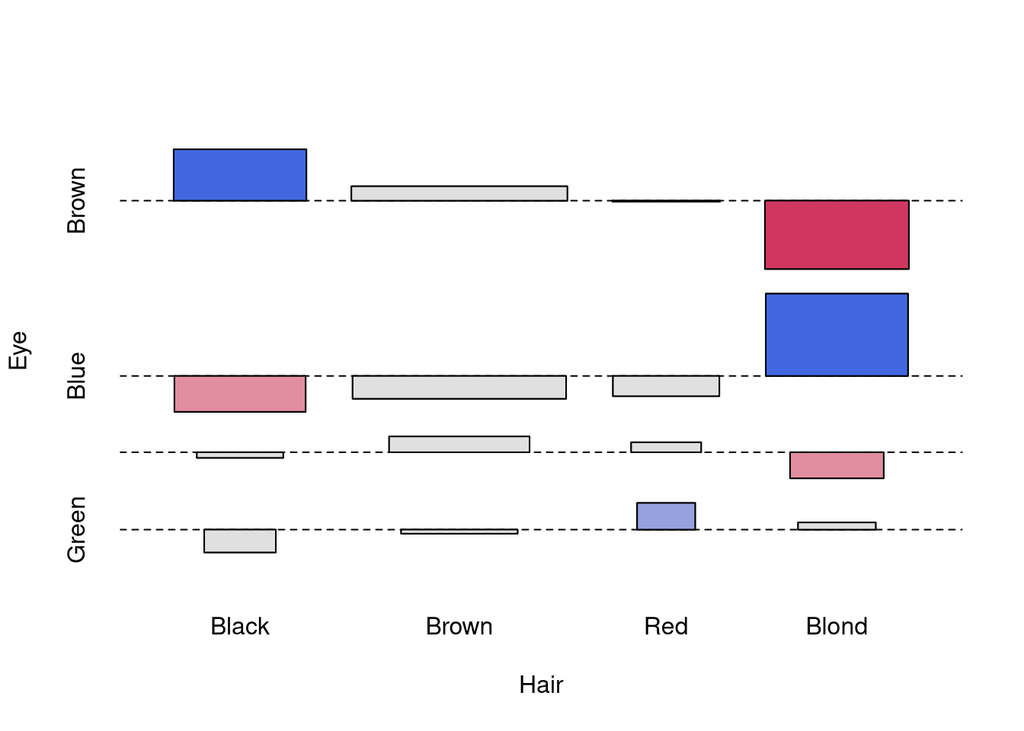

> ```r
>   x <- margin.table(HairEyeColor, c(1, 2))
>   sbi$assoc(x)
> ```

**sbi$bezier(p1,p2,p3,…)**

> Create bezier lines using three coordinates.

> This function creates bezier lines based on three coordinates. For more background information consult this discussion on [stats.stackexchange](https://stats.stackexchange.com/questions/294824/r-understanding-bezier-curves).

> Arguments:
> - *p1* - starting point as vector of x and y
> - *p2* - curve point as vector of x and y
> - *p3* - end point as vector of x and y
> - *plot* - should the curve added to an existing plot, default: FALSE
> - *arrow* - should an error be plotted if plot=TRUE, default: FALSE
> - *arrow.pos* - where the place the arrow, between 0 and 1, default: 0.55
> - *lwd* - line width for line and arrow, default: 2 _ *…* - other arguments forwarded to the line and the arrows function.

> Returns: if plot=FALSE returns list with x and y coordinates

> Examples:

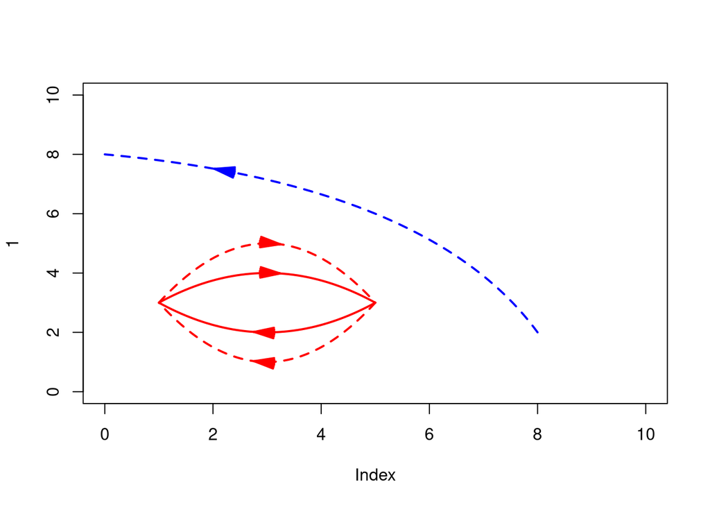

> ```r
>  plot(1,type="n",xlim=c(0,10),ylim=c(0,10))
>  sbi$bezier(c(1,3),c(3,5),c(5,3),plot=TRUE,arrow=TRUE,col="red")
>  sbi$bezier(c(1,3),c(3,7),c(5,3),plot=TRUE,arrow=TRUE,col="red",lty=2)
>  sbi$bezier(c(5,3),c(3,1),c(1,3),plot=TRUE,arrow=TRUE,col="red",lty=1)
>  sbi$bezier(c(5,3),c(3,-1),c(1,3),plot=TRUE,arrow=TRUE,col="red",lty=2)
>  sbi$bezier(c(8,2),c(6,7),c(0,8),plot=TRUE,arrow=TRUE,col="blue",
>             lty=2,arrow.pos=0.8)
> ```

**sbi$cohensD(num,cat,paired=FALSE)**

> Effect size for the difference between two means.

> The function cohensD calculates the effect size for the difference between two means. Due to Cohen’s rule of thumb values of 0.2 to 0.5 are considered to stand  
> for small effects, values from 0.5 to 0.8 represent medium effects and values above 0.8 represent large effects.  
> Alternatively you could use the biserial correlation coefficient *r* as demonstrated in the example below.

> Arguments:
> - *num* - vector with numerical values
> - *cat* - vector with two grouping variables, having the same length as num
> - *paired* - are the data paired, default: FALSE

> Returns: Cohen’s d value

> Examples:

> ```r
>   cohensD=sbi$cohensD
>   set.seed(125)
>   data(sleep)
>   with(sleep,cohensD(extra,group))
> ```

> ```
> ## [1] 0.8321811
> ```

> ```r
>   x1=rnorm(100,mean=20,sd=1)
>   x2=rnorm(100,mean=22,sd=1)
>   g1=rep('A',100)
>   g2=rep('B',100)
>   # difference should be around 2SD
>   cohensD(c(x1,x2),as.factor(c(g1,g2)))
> ```

> ```
> ## [1] 1.898655
> ```

> ```r
>   # biseriell correlation coefficient as alternative
>   # value is as well large
>   cor(c(x1,x2),as.numeric(as.factor(c(g1,g2))))
> ```

> ```
> ## [1] 0.6903109
> ```

> See also: sbi$cohensW

**sbi$cohensF(x,g)**

> Effect size for an Anova.

> The function cohensF calculates the effect size for two variables in an Anova. Due to Cohen’s rule of thumb values of 0.1 to 0.25 are considered to stand  
> for small effects, values from 0.25 to 0.4 represent medium effects and values above 0.4 represent large effects.

> Arguments:
> - *x* a numercial vector
> - *g* a factor variable with at least three levels

> Returns: Cohen’s f value

> Examples:

> ```r
>   data(iris)
>   sbi$cohensF(iris$Sepal.Width, iris$Species)
> ```

> ```
> ## [1] 0.8178289
> ```

> ```r
>   sbi$cohensF(iris$Sepal.Length, iris$Species)
> ```

> ```
> ## [1] 1.273831
> ```

> See also: sbi$cohensD, sbi$etaSquared

**sbi$cohensH(tab)**

> Effect size for a 2x2 contingency table.

> The function cohensH calculates the effect size for 2x2 contingency tables.  
> Due to Cohen’s rule of thumb values of 0.2 to 0.5 are considered to stand  
> for small effects, values from 0.5 to 0.8 represent medium effects and values above 0.8 represent large effects.

> Arguments:
> - *tab* a 2x2 contingency table

> Returns: Cohen’s h value

> Examples:

> ```r
>   # data from New Eng. J. Med. 329:297-303, 1993
>   azt=as.table(matrix(c(76,399,129,332), byrow=TRUE,ncol=2))
>   rownames(azt)=c("AZT","Placebo")
>   colnames(azt)=c("DiseaseProgress", "NoDiseaseProgress")
>   sbi$cohensH(azt)
> ```

> ```
> ## [1] 0.2917774
> ```

> See also: sbi$cohensW

**sbi$cohensW(tab)**

> Effect size for 2x2 and larger contingency tables.

> The function *sbi$cohensW* calculates the effect size for contingency tables.  
> Due to Cohen’s rule of thumb values of 0.1 to 0.3 are considered to stand  
> for small effects, values from 0.3 to 0.5 represent medium effects and values  
> above 0.5 represent large effects.

> Arguments:
> - *tab* - continency table with counts, usually created using the table  
>   command for two variables.

> Return: Cohen’s w value

> Examples:

> ```r
>   data(Titanic)
>   Titanic[1,1,,]
> ```

> ```
> ##        Survived
> ## Age      No Yes
> ##   Child   0   5
> ##   Adult 118  57
> ```

> ```r
>   sbi$cohensW(Titanic[1,1,,])
> ```

> ```
> ## [1] 0.2331907
> ```

> ```r
>   # Data from New Eng. J. Med. 329:297-303, 1993
>   azt=as.table(matrix(c(76,399,129,332), byrow=TRUE,ncol=2))
>   rownames(azt)=c("AZT","Placebo")
>   colnames(azt)=c("DiseaseProgress", "NoDiseaseProgress")
>   sbi$cohensW(azt)
> ```

> ```
> ## [1] 0.1448486
> ```

> See also: sbi$cohensH

**sbi$corr(data,method=“pearson”,use=“pairwise.complete.obs”)**

> Calculate pairwise correlations for a given data frame or matrix.

> Arguments:
> - *data* - matrix or data frame where the variables are in the columns, NA’s are allowed.
> - *method* - type of correlation to be determined, either ‘pearson’, ‘spearman’ or ‘kendall’, default: ‘pearson’
> - *use* - how to deal with NA’s, default: ‘pairwise.complete.obs’

> Returns: list with the following components:
> - *estimate* - matrix with correlation values
> - *p.value* - matrix with p-values
> - *method* - character string with the used correlation method

> Example:

> ```r
>   data(swiss)
>   lapply(sbi$corr(swiss)[1:2],round,2)
> ```

> ```
> ## $estimate
> ##                  Fertility Agriculture Examination Education Catholic
> ## Fertility             1.00        0.35       -0.65     -0.66     0.46
> ## Agriculture           0.35        1.00       -0.69     -0.64     0.40
> ## Examination          -0.65       -0.69        1.00      0.70    -0.57
> ## Education            -0.66       -0.64        0.70      1.00    -0.15
> ## Catholic              0.46        0.40       -0.57     -0.15     1.00
> ## Infant.Mortality      0.42       -0.06       -0.11     -0.10     0.18
> ##                  Infant.Mortality
> ## Fertility                    0.42
> ## Agriculture                 -0.06
> ## Examination                 -0.11
> ## Education                   -0.10
> ## Catholic                     0.18
> ## Infant.Mortality             1.00
> ##
> ## $p.value
> ##                  Fertility Agriculture Examination Education Catholic
> ## Fertility             0.00        0.01        0.00      0.00     0.00
> ## Agriculture           0.01        0.00        0.00      0.00     0.01
> ## Examination           0.00        0.00        0.00      0.00     0.00
> ## Education             0.00        0.00        0.00      0.00     0.30
> ## Catholic              0.00        0.01        0.00      0.30     0.00
> ## Infant.Mortality      0.00        0.68        0.45      0.51     0.24
> ##                  Infant.Mortality
> ## Fertility                    0.00
> ## Agriculture                  0.68
> ## Examination                  0.45
> ## Education                    0.51
> ## Catholic                     0.24
> ## Infant.Mortality             0.00
> ```

> See also: sbi$corrplot

**sbi$corplot(x,y,col=‘red’,pch=19,…)**

> Visualize a correlation with abline.

> Arguments:
> - *x* - numerical vector
> - *y* - numerical vector
> - *col* - plotting character color
> - *pch* - the plotting symbol for the correlations, default: 19
> - *method* - the correlation method, ‘pearson’, ‘spearman’ or ‘kendall’, default: ‘pearson’
> - *…* - arguments delegated to the plot function

> Example:

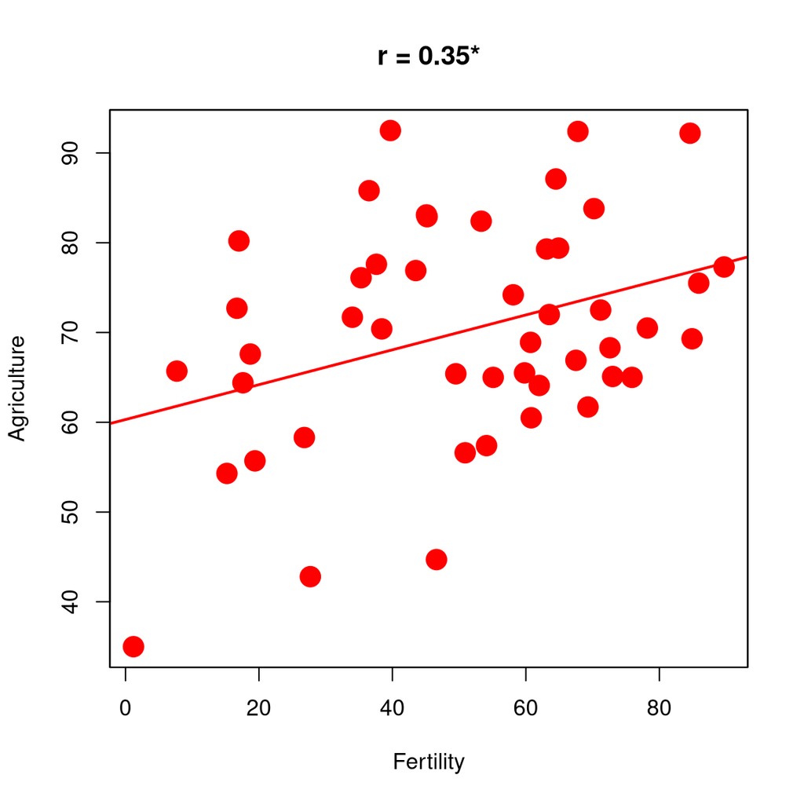

> Corplot with abline

> ```r
>   data(swiss)
>   sbi$corplot(swiss$Fertility,swiss$Agriculture,
>     xlab="Fertility",ylab="Agriculture")
> ```

> See also: sbi$corrplot

**sbi$corrplot(mt,…)**

> Visualize a correlation matrix.

> Arguments:
> - *mt* - matrix with pairwise correlations
> - *text.lower* - should in the lower diagonal the correlation coefficient be shown, default: TRUE
> - *text.upper* - should in the upper diagonal the correlation coefficient be shown, default: FALSE
> - *pch* - the plotting symbol for the correlations, default: 19
> - *p.mat* - matrix with p-values to strike out insignificant p-values, default: NULL (not used)
> - *alpha* - significance threshold for *p.mat*, default: 0.05
> - *cex.sym* - character expansion for the correlation symbols, default: 5
> - *cex.r* - character expansion for the r-values if *text.lower* or *text.upper* are set to TRUE, default: 1
> - *cex.lab* - character expansion for the variable text labels, default: 1.4
> - *…* - arguments delegated to the plot function

> Example:

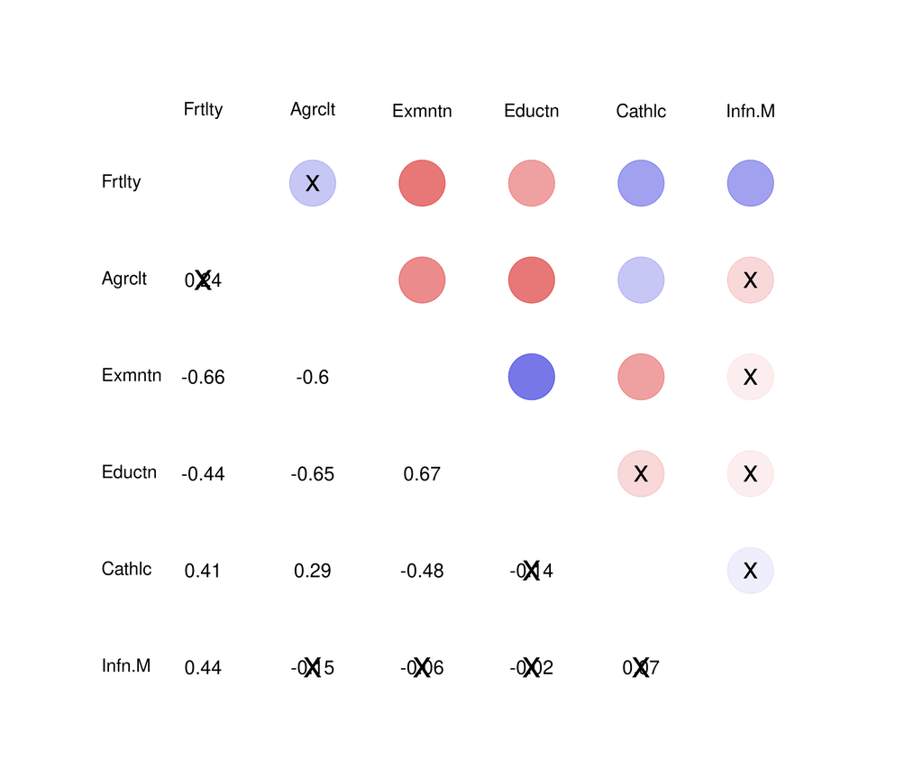

> ```r
> data(swiss)
> sw=swiss
> colnames(sw)=abbreviate(colnames(swiss),6)
> options(warn=-1) # avoid spearman warnings
> cr=sbi$corr(sw,method='spearman')
> sbi$corrplot(cr$estimate,cex.sym=8,text.lower=TRUE,
>    cex.r=1.5,p.mat=cr$p.value)
> ```

> ```r
> options(warn=0)
> ```

> See also: sbi$corr

**sbi$cor.var(x,r,mean=0,sd=1)**

> Create a vector with a given correlation to another vector.

> Arguments:
> - *x* - vector numerical values
> - *r* - correlation value between -1 and 1
> - *mean* - mean for the requested data vector, default: 0
> - *sd* - standard deviation for the requested data vector, default: 1

> Returns: numerical vector having the requested pearson correlation to x

> Example:

> ```r
>   set.seed(123)
>   A=rnorm(300,mean=160,sd=6)
>   B=sbi$cor.var(A,r=0.7,mean=80,sd=4)
>   C=sbi$cor.var(A,r=0.5,mean=40,sd=2)
>   D=sbi$cor.var(B,r=0.4,mean=18,sd=1)
>   E=sbi$cor.var(D,r=0.4,mean=30,sd=1)
>   df=data.frame(A=A,B=B,C=C,D=D,E=E)
>   summary(df)
> ```

> ```
> ##        A               B               C               D
> ##  Min.   :146.1   Min.   :68.76   Min.   :34.61   Min.   :15.37
> ##  1st Qu.:156.5   1st Qu.:77.59   1st Qu.:38.86   1st Qu.:17.32
> ##  Median :159.7   Median :80.18   Median :40.33   Median :18.02
> ##  Mean   :160.2   Mean   :80.04   Mean   :40.17   Mean   :17.98
> ##  3rd Qu.:163.8   3rd Qu.:82.75   3rd Qu.:41.54   3rd Qu.:18.70
> ##  Max.   :179.4   Max.   :90.29   Max.   :46.58   Max.   :20.74
> ##        E
> ##  Min.   :27.32
> ##  1st Qu.:29.32
> ##  Median :29.99
> ##  Mean   :30.00
> ##  3rd Qu.:30.70
> ##  Max.   :32.54
> ```

> ```r
>   round(cor(df),2)
> ```

> ```
> ##      A    B    C    D    E
> ## A 1.00 0.70 0.49 0.22 0.04
> ## B 0.70 1.00 0.35 0.39 0.18
> ## C 0.49 0.35 1.00 0.07 0.04
> ## D 0.22 0.39 0.07 1.00 0.39
> ## E 0.04 0.18 0.04 0.39 1.00
> ```

> See also: sbi$cor.vars

**sbi$cor.vars(n,r.matrix,mu.vec=rep(0,ncol(r.matrix))**

> Create a data frame with n values for each varaible of the given correlation matrix.

> Arguments:
> - *n* - number of values for each variable
> - *r.matrix* - matrix of correlation values, must be symmetric
> - *mu.vec* - means for the values of each variable, default: 0

> Returns: data frame of size *n x ncol(r.matrix)*

> Example:

> ```r
> r.mt=matrix(c(1,0.7,0.4, 0.7,1,0.3, 0.4,0.3,1),
>      byrow=TRUE,ncol=3)
> mt.vars=sbi$cor.vars(100,r.mt,c(1,10,5))
> summary(mt.vars)
> ```

> ```
> ##        V1                V2               V3
> ##  Min.   :-1.2171   Min.   : 7.891   Min.   :2.695
> ##  1st Qu.: 0.3577   1st Qu.: 9.305   1st Qu.:4.409
> ##  Median : 0.9705   Median :10.110   Median :4.930
> ##  Mean   : 1.0000   Mean   :10.000   Mean   :5.000
> ##  3rd Qu.: 1.7245   3rd Qu.:10.673   3rd Qu.:5.763
> ##  Max.   : 3.4225   Max.   :12.720   Max.   :8.151
> ```

> ```r
> cor(mt.vars)
> ```

> ```
> ##      [,1] [,2] [,3]
> ## [1,]  1.0  0.7  0.4
> ## [2,]  0.7  1.0  0.3
> ## [3,]  0.4  0.3  1.0
> ```

> See also: sbi$cor.var * sbi$chr2ord - convert factors or characters to ordinal numbers

**sbi$chr2ord(x,map)**

> Create ordinal numerical variables out of character or factor variables based on a given mapping.

> Arguments:
> - *x* - character for factor vector
> - *map* - list with keys for the given x vector and numbers for the matching values

> Returns: numerical values for the mapping

> Example:

> ```r
> status=c("never","rare","often","always")
> x=sample(status,100,replace=TRUE)
> x=c(NA,x,NA)
> table(x,useNA='ifany')
> ```

> ```
> ## x
> ## always  never  often   rare   <NA>
> ##     22     30     25     23      2
> ```

> ```r
> map=c(never=0, rare=1, often=2,always=3)
> table(sbi$chr2ord(x,map),useNA='ifany')
> ```

> ```
> ##
> ##    0    1    2    3 <NA>
> ##   30   23   25   22    2
> ```

**sbi$cv(x,na.rm=FALSE)**

> Calculate the coefficient of variation.

> Arguments:
> - *x* - vector with positive numerical values.
> - *na.rm* - should NA’s be removed, default: FALSE

> Returns: numerical value for the coefficient of variation.

> Example:

> ```r
>   cv=sbi$cv
>   cv(rnorm(20,mean=100,sd=4))
> ```

> ```
> ## [1] 4.094347
> ```

> ```r
>   cv(c(1,2,3,4))
> ```

> ```
> ## [1] 51.63978
> ```

> ```r
>   cv(c(1,2,3,4,NA))
> ```

> ```
> ## [1] NA
> ```

> ```r
>   cv(c(1,2,3,4,NA),na.rm=TRUE)
> ```

> ```
> ## [1] 51.63978
> ```

**sbi$dict(…)**

> Create list with keys and values, ensuring unique keys (dictionary).

> Arguments:
> - *…* - arguments with *key=value* pairs

> Returns: a key-value list with unique keys

> Example:

> ```r
>   options(error=print)
>   # list's can have duplicate entries
>   l=list(a=1,a=2)
>   l$a
> ```

> ```
> ## [1] 1
> ```

> ```r
>   l[1]
> ```

> ```
> ## $a
> ## [1] 1
> ```

> ```r
>   l[2]
> ```

> ```
> ## $a
> ## [1] 2
> ```

> ```r
>   # dict's can't ...
>   try({d=sbi$dict(a=1,a=1)})
> ```

> ```
> ## Error in sbi$dict(a = 1, a = 1) : Error: dict must have key value pairs
> ##          and keys can not be duplicated!
> ```

> ```r
>   d=sbi$dict(a=1,b=2)
>   d
> ```

> ```
> ## $a
> ## [1] 1
> ##
> ## $b
> ## [1] 2
> ```

> ```r
>   sbi$is.dict(d)
> ```

> ```
> ## [1] TRUE
> ```

> ```r
>   options(error=NULL)
> ```

**sbi$dpairs(data,…)**

> Improved pairs plot considering the data types.

> The function *dpairs* provides an improved pairs plot which accounts for the data type of the actual variables. It will plot in the  
> lower diagonal xy-plots, box-plots or assoc-plots depending on the  
> two data types. In the upper diagonal effect sizes and stars for the p-values for the tests (anova, t.test, chisq.test or cor.test will be shown. In the diagonal  
> the data distribution will be outlined. This plot is usually an useful visualization for 3-8 variables.

> Arguments:
> - *data* - data frame with columns of class factor, numeric or integer.
> - *col.box* - colors for the boxplots, either a single value or a vector of colors for each level of a factor variable, default; ‘grey80’
> - *col.xy* - colors for the xy-plots, either a single value of a vector which is as long as the number of data points, default: ‘grey60’
> - *cex.diag* - character expansion for the diagonal texts
> - *order* - should the variables be ordered by data type and name, this is recommended as it orders the plots, starting with assocplots, then boxplots and finally xyplots, default: TRUE
> - *pch* - plotting character for xy-plots, default 19 (round circle).

> Example:

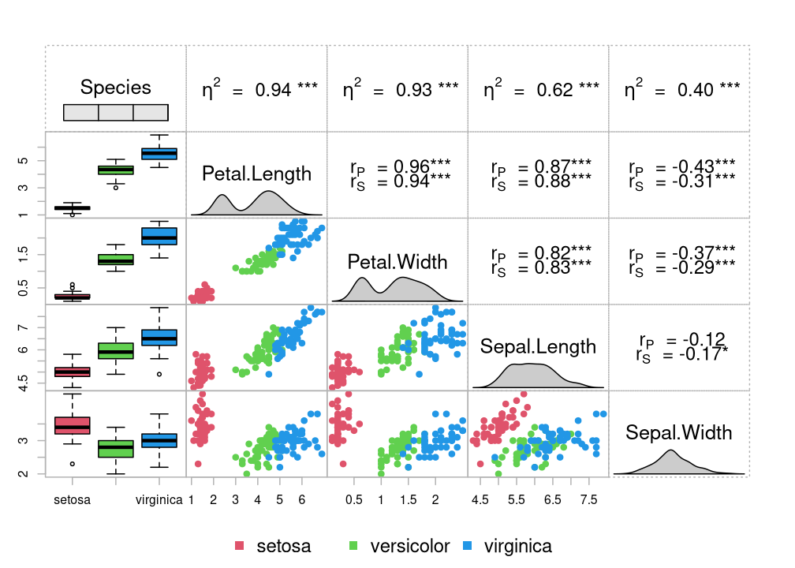

> ```r
>   data(iris)
>   dpairs=sbi$dpairs
>   par(omi = c(0.8, 0.4,0.4,0.4))
>   dpairs(iris,col.box=2:4,col.xy=rep(c(2:4),each=50),
>      cex.diag=1.6)
>   sbi$dpairs.legend(levels(iris$Species),col=2:4,cex=1)
> ```

**sbi$dpairs.legend(labels,col=‘grey80’,pch=15, side=‘bottom’)**

> Adding legend top or bottom to a *sbi$dpairs* or teh standard *pairs* plot.

> The function *sbi$dpairs.legend* allows the user to place a legend outside of a  
> pairs or dpairs plot.

> Arguments:
> - *labels* - txt labels to be plotted
> - *col* - colors for the plotting characters
> - *pch* - plotting symbol, default 15
> - *side* - where to place the legend, ‘top’ or ‘bottom’, default: ‘bottom’
> - *cex* - the character expansion for the legend, default: 2

**sbi$drop_na(x,cols)**

> Removes all rows where any of the columns contain a NA.

> In contrast to *na.omit*, the method *sbi$drop_na* just checks the given columns  
> to delete rows which have any NA in these two columns in the given rows.  
> This mimics the tidyr::drop_na function.

> Arguments:
> - *x* - data frame or matrix
> - *cols* - column names to check for NA’s.

> Example:

> ```r
> data(iris)
> ir=iris
> ir[c(1,3),1]=NA
> ir[2,2]=NA
> ir[4,4]=NA
> head(ir)
> ```

> ```
> ##   Sepal.Length Sepal.Width Petal.Length Petal.Width Species
> ## 1           NA         3.5          1.4         0.2  setosa
> ## 2          4.9          NA          1.4         0.2  setosa
> ## 3           NA         3.2          1.3         0.2  setosa
> ## 4          4.6         3.1          1.5          NA  setosa
> ## 5          5.0         3.6          1.4         0.2  setosa
> ## 6          5.4         3.9          1.7         0.4  setosa
> ```

> ```r
> head(na.omit(ir)) # removes all rows with an NA somewhere
> ```

> ```
> ##    Sepal.Length Sepal.Width Petal.Length Petal.Width Species
> ## 5           5.0         3.6          1.4         0.2  setosa
> ## 6           5.4         3.9          1.7         0.4  setosa
> ## 7           4.6         3.4          1.4         0.3  setosa
> ## 8           5.0         3.4          1.5         0.2  setosa
> ## 9           4.4         2.9          1.4         0.2  setosa
> ## 10          4.9         3.1          1.5         0.1  setosa
> ```

> ```r
> head(sbi$drop_na(ir,1:2)) # just checks the first two columns
> ```

> ```
> ##   Sepal.Length Sepal.Width Petal.Length Petal.Width Species
> ## 4          4.6         3.1          1.5          NA  setosa
> ## 5          5.0         3.6          1.4         0.2  setosa
> ## 6          5.4         3.9          1.7         0.4  setosa
> ## 7          4.6         3.4          1.4         0.3  setosa
> ## 8          5.0         3.4          1.5         0.2  setosa
> ## 9          4.4         2.9          1.4         0.2  setosa
> ```

**sbi$epsilonSquared(x,y=NULL)**

> Calculate the effect size epsilon-squared for variables of a kruskal.test Cohen’s rule of thumb for interpretation is: 0.01-0.09 small, 0.09-0.25 medium and above 0.25 large effect. You can convert eta-squared to a Spearman *r* by using the square root of epsilon-square.

> Arguments:
> - *x* - vector with numerical values or a linear model or an aov object.
> - *y* - vector with factor values or numerical vector of a second class

> Returns: numerical value for epsilon-square for given variables.

> Example:

> ```r
>   data(iris)
>   sbi$epsilonSquared(iris$Sepal.Length,iris$Species)
> ```

> ```
> ## [1] 0.6505868
> ```

> ```r
>   # two factor example as well for wilcox.test possible
>   data(ToothGrowth)
>   sbi$epsilonSquared(ToothGrowth$len,as.factor(ToothGrowth$dose))
> ```

> ```
> ## [1] 0.689304
> ```

> ```r
>   # close to r-square of spearman!
>   cor(ToothGrowth$len,ToothGrowth$dose,method="spearman")^2
> ```

> ```
> ## [1] 0.6861496
> ```

> See also: sbi$etaSquared

> Todo: Check for correctness … too many formula’s around, I used that one from Tomczak and Tomczak (2014).

**sbi$etaSquared(x,y=NULL)**

> Calculate the effect size eta-squared for an Anova or a linear model.  
> Cohen’s rule of thumb for interpretation is: 0.01-0.09 small, 0.09-0.25 medium and above 0.25 large effect. You can convert eta-squared to a Pearson r by using the sqrt of eta-square.

> Arguments:
> - *x* - vector with numerical values or a linear model or an aov object.
> - *y* - either f factor or NULL if x is given as model.

> Returns: numerical value for eta-squares for all given variables in the model x or the value for the variable given in y if x is a numerical variable.

> Example:

> ```r
>   data(iris)
>   etaSquared=sbi$etaSquared
>   etaSquared(iris$Sepal.Length,iris$Species)
> ```

> ```
> ## [1] 0.6187057
> ```

> ```r
>   etaSquared(lm(iris$Sepal.Length ~ iris$Species))
> ```

> ```
> ## [1] 0.6187057
> ```

> ```r
>   etaSquared(aov(iris$Sepal.Length ~ iris$Species))
> ```

> ```
> ## iris$Species
> ##    0.6187057
> ```

> ```r
>   etaSquared(aov(Sepal.Length ~ Species+Sepal.Width+Petal.Length,data=iris))
> ```

> ```
> ## Species      Sepal.Width  Petal.Length
> ##    0.6187057    0.1072009    0.1374022
> ```

> See also: sbi$cohensF, sbi$cohensD, sbi$epsilonSquared.

**sbi$file.cat(filename)**

> Displays a file to the terminal, not to stdout.

> Arguments:
> - *filename* - filename of a text file

> Example:

> ```r
>   sbi.code=sbi$file.cat(sbi$FILENAME)
>   nchar(sbi.code)
> ```

> ```
> ## [1] 114533
> ```

> See also: sbi$file.head

**sbi$file.head(filename,n=6)**

> Displays the first n lines of a file to the terminal

> Arguments:
> - *filename* - filename of a text file
> - *n* - number of first lines to display, default: 6

> Returns: Nothing.

> Example:

> ```r
>   sbi$file.head(sbi$FILENAME,n=10)
> ```

> ```
> ##  [1] "#!/usr/bin/env Rscript"
> ##  [2] "#' ---"
> ##  [3] "#' title: SBI 2022 - sbi.R - functions and operators"
> ##  [4] "#' author: Detlef Groth, University of Potsdam"
> ##  [5] "#' date: 2022-05-09"
> ##  [6] "#' ---"
> ##  [7] "#' "
> ##  [8] "## include \"../header.md\""
> ##  [9] "#' "
> ## [10] "#' ## R functions for Statistical Bioinformatics - 2022-05-09"
> ```

> See also: sbi$file.cat

**sbi$flow(x,y,lab=““,…)**

> Very simple flowcharter. For more advanced flowcharts use package like diagram.

> Arguments:
> - *x* - coordinate(s) in chessboard notation like ‘A1’, ‘C3’, etc
> - *y* - coordinate(s) in chessboard notation like ‘A1’, if given we assume a line or arrow, otherwise a node, default: NULL
> - *z* - coordinate(s) in chessboard notation, x, y and z are used for bezier curves/arrow, default: NULL
> - *x.incr* - optional increment in x direction, default: 0
> - *y.incr* - options increment in y direction, default: 0
> - *lab* - label(s) for a node shown as rectangle, default: “” _ *family* - the font family for the node labels, an be only set at initialzation of the flowchart, so different fonts for different labels are not possible, default: ‘Arial’
> - *type* - if y is given, either “arrow” or “line”, in case only x is given either “text”, “rect”, “ellipse”, “circle”,“hexagon” or “diamond”, default: “arrow” or “rect”
> - *axes* - should to plot axes been shown, default: FALSE
> - *lwd* - linewidth for arrows or lines, default: 2
> - *width* - width of shape, default: 0.6
> - *height* - height of shape, default: 0.3
> - *cex* - text expansion for rectangle labels, default: 1
> - *col* - background color(s) for rectangle, default: “skyblue”
> - *border* - border color for rectangle, default: “black”
> - *arrow.col* - color for arrows and lines, default: “black”
> - *cut* - relative position (0..1) where to place the arrow, default: 0.6
> - *shadow* - should a shadow been shown around the rectangle, default: TRUE
> - *shadow.col* - color of the shadow, default: “#bbbbbb90”
> - *…* - remaining arguments delegated to the plot function, the rectangle function and so on

> **Hint**: If plural is given such as coordinates(s), label(s), colors(s) arguments can be given as well as vectors, having the same length as x.

> Returns: Nothing.

> Example:

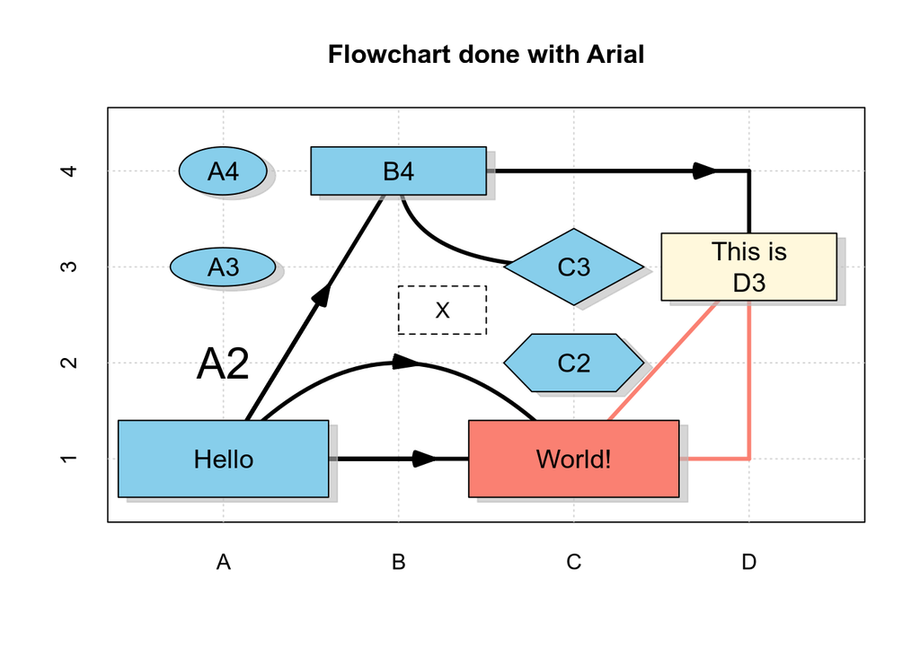

> ```r
> font="Arial"
> # setup a more interesting font if available
> # stick to Arial if not
> if (require("extrafont",quietly=TRUE)) {
>    loadfonts(device="pdf",quiet=TRUE)
>    if ("Albertus Medium" %in% extrafont::fonts()) {
>         font="Albertus Medium"
>    } else if ("Georgia" %in% extrafont::fonts()) {
>         font="Georgia"
>    }
> }
> flow=sbi$flow
> flow(4,4,axes=TRUE,cex.axis=3,family=font)
> grid()                       # make it more chessboard like
> # if you are happy with the layout you could remove at the end
> # the axes and grid commands / options at the beginning
> flow("A1","C1",lwd=3)        # first edges
> flow("A1","B4",lwd=3)
> flow("B4","D4",lwd=3,cut=0.9)       # arrow around the corner
> flow("D4","D3",lwd=3,type="line")   # ... continued
> flow("C1","D3",lwd=3,arrow.col="salmon",type="line") # a line
> flow("C1","D1",lwd=3,arrow.col="salmon",type="line") # a line
> flow("D1","D3",lwd=3,arrow.col="salmon",type="line") # ...
> # Bezier lines
> flow(x="A1",y="B3",z="C1",lwd=3,cut=0.55)
> flow(x="B4",y="B3",z="C3",type="line",lwd=3,col="salmon")
> # nodes
> flow("A1",lab="Hello",width=1.2,height=0.8,cex=1.2) # then nodes
> flow("C1",lab="World!",col="salmon",width=1.2,height=0.8,cex=1.2)
> flow("B4",lab="B4",cex=1.2)
> flow("D3",lab="This is\nD3",cex=1.2,col="cornsilk",height=0.7)
> # other shapes
> flow("A3",lab="A3",type="ellipse",cex=1.2,width=0.6,height=0.4)
> flow("A2",lab="A2",type="text",cex=2)
> flow("A4",lab="A4",type="circle",cex=1.2,width=0.5,height=0.5)
> flow("C3",lab="C3",type="diamond",cex=1.2,width=0.8,height=0.8)
> flow("C2",lab="C2",type="hexagon",cex=1.2,width=0.8,height=0.6)
> # basic draw operations still work
> rect(2,2.3,2.5,2.8,lty=2)
> text(2.25,2.55,"X",family=font)
> title(paste("Flowchart done with",font),family=font)
> ```

Here an other example with a more regular shape. The C-Major and the C-pentatonic scale on an Ukulele:

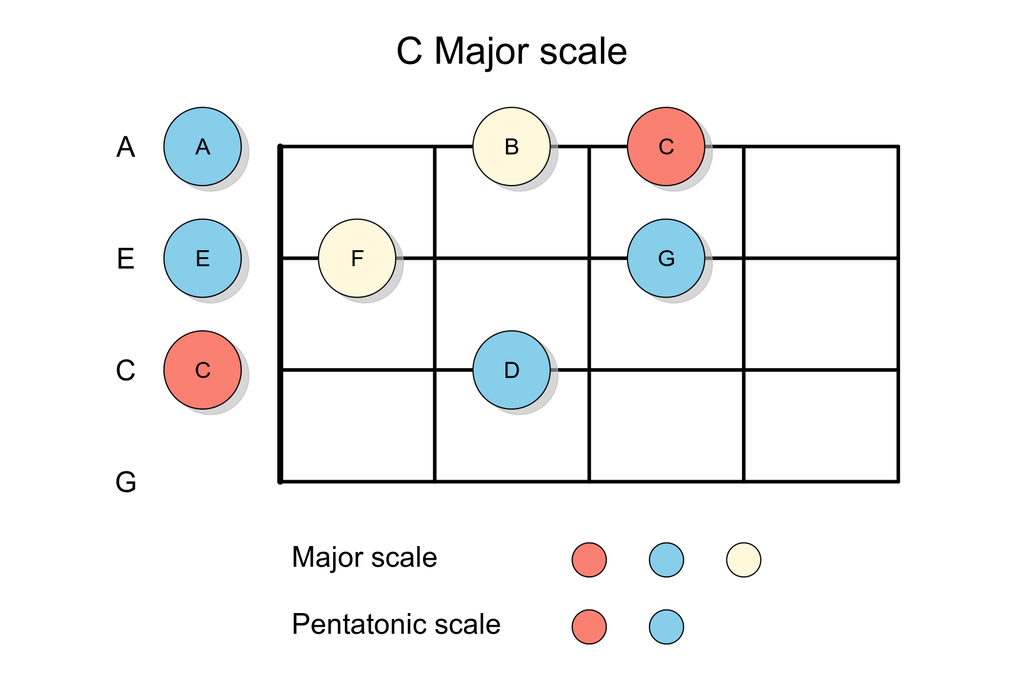

> ```r
> par(mai=c(0.1,0.1,0.6,0.1))
> flow=sbi$flow
> flow(6,5,axes=FALSE,cex.axis=3,family=font,asp=0)
> # grid()
> # strings
> flow(c("B2","B3","B4","B5"),
>      c("F2","F3","F4","F5"),lwd=3,type="line")
> # bridge
> flow("B2","B5",lwd=5,type="line")
> # frets
> flow(c("C2","D2","E2","F2"),
>      c("C5","D5","E5","F5"),lwd=3,type="line")
> # string notes
> flow(c("A2","A3","A4","A5"),
>  lab=c("G" ,"C" ,"E" ,"A"),type="text",cex=1.5)
> #  notes (as loop example)
> df=data.frame(
>     pos=c("A3","C3","A4","B4","D4","A5","C5","D5"),
>     note=strsplit("C D E F G A B C", " ")[[1]],
>     col=strsplit("salmon skyblue skyblue cornsilk skyblue skyblue cornsilk salmon", " ")[[1]]);
> for (i in 1:nrow(df)) {
>    flow(df$pos[i],x.incr=0.5,type="circle",width=0.5,height=0.7,
>     lab=df$note[i],col=df$col[i],cex=1.2)
> }
> # still direct setup is possible
> text(2,1.3,"Major scale",pos=4,family=font,cex=1.5)
> text(2,0.7,"Pentatonic scale",pos=4,family=font,cex=1.5)
> points(c(4,4.5,5),c(1.3,1.3,1.3),pch=21,cex=4,bg=c("salmon","skyblue","cornsilk"),col=1)
> points(c(4,4.5),c(0.7,0.7),pch=21,cex=4,bg=c("salmon","skyblue"),col=1)
> mtext("C Major scale",side=3,cex=2,family=font)
> ```

> See also: [Resolve issue with extrafont](https://stackoverflow.com/questions/61204259/how-can-i-resolve-the-no-font-name-issue-when-importing-fonts-into-r-using-ext)

**sbi$fmt(text,…)**

> Python like formatting of strings using curly braces.

> Arguments:
> - *text* - text with curly braces as placeholders
> - *…* - replacement texts or numerical values

> Returns: replaced text

> Example:

> ```r
>   sbi$fmt('I can say {} {}!',"Hello", "World")
> ```

> ```
> ## [1] "I can say Hello World!"
> ```

> ```r
>   sbi$fmt('I can say {2} {1}!',"World", "Hello")
> ```

> ```
> ## [1] "I can say Hello World!"
> ```

**sbi$gmean(x,na.rm=FALSE)**

> Calculate the geometric mean of a numerical vector. All values in *x* should be above zero.

> Arguments:
> - *x* - vector with positive numerical values.
> - *na.rm* - should NA’s be removed, default: FALSE

> Returns: numerical value for the geometric mean.

> Example:

> ```r
>   gmean=sbi$gmean
>   x=10; y=20; z = 30
>   gmean(c(x,y,z))
> ```

> ```
> ## [1] 18.17121
> ```

> ```r
>   gmean(c(x+0.5*x,y,z))
> ```

> ```
> ## [1] 20.80084
> ```

> ```r
>   gmean(c(x,y+0.5*y,z))
> ```

> ```
> ## [1] 20.80084
> ```

> ```r
>   gmean(c(x,y,z+z*0.5))
> ```

> ```
> ## [1] 20.80084
> ```

**sbi$hmean(x,na.rm=FALSE)**

> Calculate the harmonic mean for a numerical vector, the mean of ratios.

> Arguments:
> - *x* - vector with positive numerical values.
> - *na.rm* - should NA’s be removed, default: FALSE

> Returns: numerical value for the harmonic mean.

> Example:

> ```r
>   hmean=sbi$hmean
>   hmean(c(60,30)) # average speed
> ```

> ```
> ## [1] 40
> ```

> ```r
>   hmean(c(60,30,0)) # speed is zero
> ```

> ```
> ## [1] 0
> ```

**sbi$import(basename)**

> Module like sourcing of R files relative to the main script.  
> As the source command in R can’t use relative filenames, the import function can be used if the Rscript interpreter is used to source other R source code files using relative filepaths in relation to the main script file. The basename must be given without the file extension, usually *.r* or *.R*.  
> This function works only in non-interactive mode if the Rscript interpreter was  
> used to execute the main script.

> Arguments:
> - *basename* - relative path to the R script in relationship to the main script without the *.R* or *.r* extension

> Returns: nothing

> Example:

> ```r
>   fout = file("test.R",'w')
>   cat("test = function (msg) { return(paste('testing',msg)) }\n",file=fout)
>   close(fout)
>   sbi$import('test')
> ```

> ```
> ## [1] "loading test.R !"
> ```

> ```r
>   test("Hello from test!")
> ```

> ```
> ## [1] "testing Hello from test!"
> ```

**sbi$input(prompt)**

> Replacement for the readline function in non-interactive scripts.  
> As the readline function does only works in interactive mode we need an alternative.

> Arguments:
> - *prompt* - text displayed to ask for input of the user.

> Returns: input entered by the user as string.

> Example:

> ```r
> # notrun
> x=sbi$input('Enter a numerical value: ')
> x=as.numeric(x)
> print(paste("x*x is",x*x))
> ```

**sbi$is.dict(listvar)**

> Check if the given list is a key-value list with unique keys.

> Arguments:
> - *listvar* - an object of class list

> Returns: TRUE if the list has unique keys for every value, otherwise FALSE

> Example:

> ```r
>   is.dict=sbi$is.dict
>   l=list(1,2,"b")
>   is.dict(l)
> ```

> ```
> ## [1] FALSE
> ```

> ```r
>   l=list(a=1,b=2,a=3)
>   is.dict(l)
> ```

> ```
> ## [1] FALSE
> ```

> ```r
>   l=list(a=1,b=2,c=3)
>   is.dict(l)
> ```

> ```
> ## [1] TRUE
> ```

**sbi$mkdoc(infile,cssfile=“mini.css”,eval=TRUE)**

> Extract embedded Markdown documentation after `#'` and convert it into HTML. Further include constructs like ’## include “header.md” are supported.

> Returns: NULL

> Example:

> ```r
> # creating sbi.html, the file you are viewing
> mkdoc("sbi.R",eval=TRUE)
> ```

**sbi$lmPlot(x,y,…)**

> A xy-plot with linear model and the confidence intervals.

> This method can be used to visualize the confidence intervals for  
> the predictions and the linear model.

> Arguments:
> - *x* - numerical vector
> - *y* - numerical vector
> - *col* - scalar or vector for the color for the plotting character default: ‘blue’
> - *pch* - the plotting character, default: 19
> - *col.lm* - color for the regression line and their confidence interval, default: ‘red’
> - *col.pi* - color for the prediction confidence interval, default: ‘blue’
> - *grid* - should a grid be drawn in the plot, default: TRUE
> - *polygon* - should the confidence interval for the regression line been shown as transparent polygon, default: TRUE
> - *…* - other arguments which will be forwarded to the plot function

> Example:

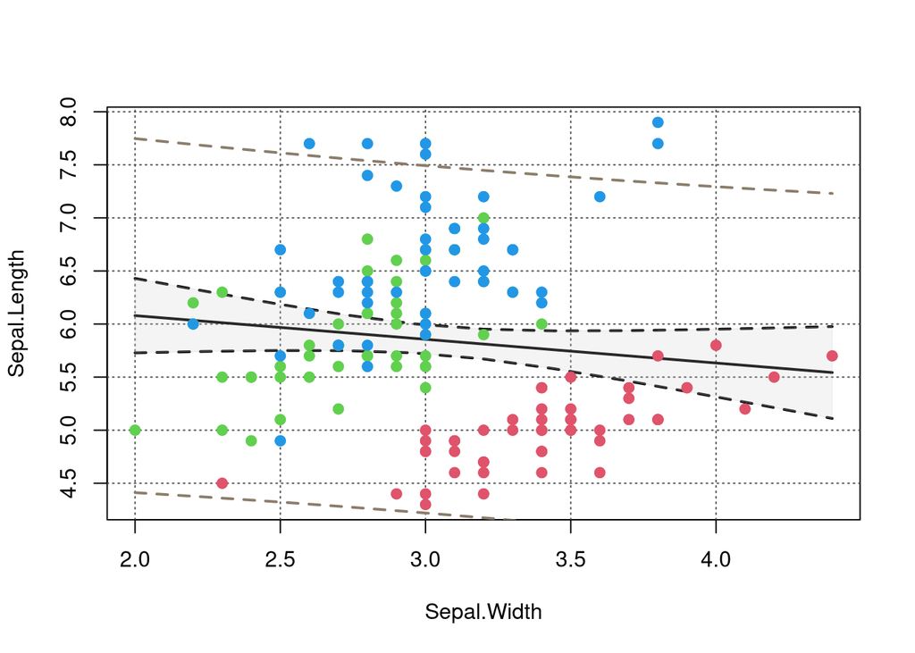

> ```r
> data(iris)
> sbi$lmPlot(iris$Sepal.Width, iris$Sepal.Length,
>    col=as.numeric(iris$Species)+1,col.pi="bisque4",
>    col.lm="black",xlab="Sepal.Width",ylab="Sepal.Length")
> ```

> See also: sbi$skewness

**sbi$kurtosis(x,na.rm=FALSE)**

> Calculate the fourth central moment of a distribution. Values higher than 0 indicate heavy-tailed distributions, values of lower than zero means  
> light-tailed (sharp peak) distributions. Values around zero mean normal value like distribution. As the normal kurtosis formula has for normal distributions a value of three, usually the excess kurtosis as in this implementation is  
> used which involves substraction of 3.

> Arguments:
> - *x* - vector with positive numerical values.
> - *na.rm* - should NA’s be removed, default: FALSE

> Returns: numerical value for the excess kurtosis.

> Example:

> ```r
>   sbi$kurtosis(1:10)      # very uniform, should be negative
> ```

> ```
> ## [1] -1.561636
> ```

> ```r
>   sbi$kurtosis(runif(10,min=1,max=5)+rnorm(10,mean=3,sd=0.2))
> ```

> ```
> ## [1] -0.4654305
> ```

> ```r
>   sbi$kurtosis(rnorm(100,mean=10,sd=0.5)) # close to zero
> ```

> ```
> ## [1] -0.5332394
> ```

> ```r
>   sbi$kurtosis(rt(50,df=1)) # higher than normal
> ```

> ```
> ## [1] 42.93927
> ```

> See also: sbi$skewness

**sbi$mhist(y,groups,cols=NULL,…)**

> Lattice like histograms.

> This function creates for 2-4 groups histograms with a stripe on top using the same y-scales for all groups.

> Examples:

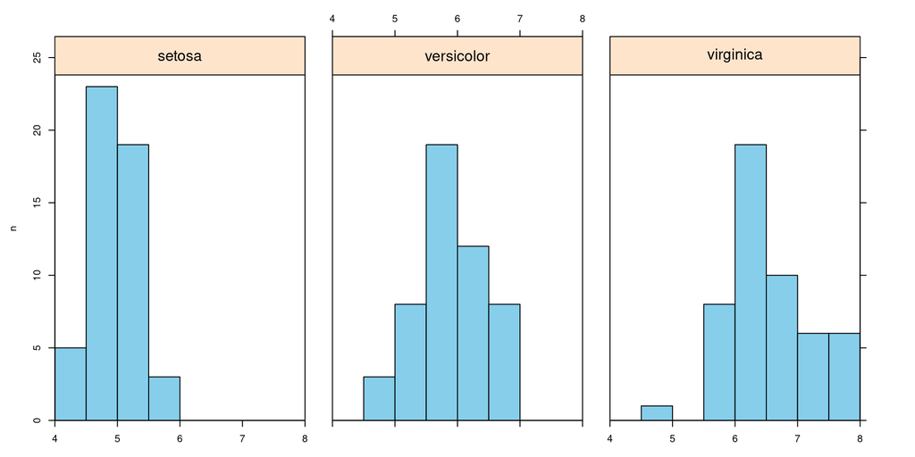

> ```r
>   data(iris)
>   sbi$mhist(iris$Sepal.Length,iris$Species,cols="skyblue")
> ```

**sbi$mi(x,y=NULL, breaks=4)**

> Return the mutual information for two vectors or a binned table.

> Arguments:
> - *x* - either a binned table, a matrix or data.frame or a numerical vector
> - *y* - a numerical vector if x is not a binned table or matrix or data.frame
> - *breaks* - number of breaks to create a binned table if x and y are numerical vectors, default: 4
> - *norm* - if input is given should the matrix be normalized by dividing the off-diagonal values by the mutual information in the diagonals, so the self mutual information, default: FALSE

> Returns: mutual information value as scalar if inout is table or two vectors or as matrix if input is matrix or data.frame

> Example:

> ```r
>   rn1=rnorm(100,mean=10,sd=1);
>   rn2=rn1+0.5*rnorm(100)
>   cor(rn1,rn2) # high
> ```

> ```
> ## [1] 0.9133258
> ```

> ```r
>   cor(rn1,sample(rn2)) #random
> ```

> ```
> ## [1] 0.05267705
> ```

> ```r
>   sbi$mi(rn1,rn2) # high
> ```

> ```
> ## [1] 0.5946916
> ```

> ```r
>   sbi$mi(rn1,sample(rn2)) #random
> ```

> ```
> ## [1] 0.04536333
> ```

> ```r
>   sbi$mi(rn1,rn2,breaks=4)
> ```

> ```
> ## [1] 0.5946916
> ```

> ```r
>   sbi$mi(rn1,rn2,breaks=7)
> ```

> ```
> ## [1] 0.782973
> ```

> ```r
>   data(swiss)
>   round(sbi$mi(swiss),2)
> ```

> ```
> ##                  Fertility Agriculture Examination Education Catholic
> ## Fertility             1.14        0.05        0.19      0.26     0.46
> ## Agriculture           0.05        1.36        0.28      0.16     0.18
> ## Examination           0.19        0.28        1.22      0.16     0.33
> ## Education             0.26        0.16        0.16      0.62     0.21
> ## Catholic              0.46        0.18        0.33      0.21     0.94
> ## Infant.Mortality      0.14        0.18        0.15      0.12     0.08
> ##                  Infant.Mortality
> ## Fertility                    0.14
> ## Agriculture                  0.18
> ## Examination                  0.15
> ## Education                    0.12
> ## Catholic                     0.08
> ## Infant.Mortality             1.09
> ```

> ```r
>   round(sbi$mi(swiss,norm=TRUE),2)
> ```

> ```
> ##                  Fertility Agriculture Examination Education Catholic
> ## Fertility             1.00        0.05        0.17      0.23     0.41
> ## Agriculture           0.04        1.00        0.21      0.12     0.13
> ## Examination           0.16        0.23        1.00      0.13     0.27
> ## Education             0.42        0.25        0.26      1.00     0.33
> ## Catholic              0.49        0.19        0.35      0.22     1.00
> ## Infant.Mortality      0.13        0.17        0.14      0.11     0.08
> ##                  Infant.Mortality
> ## Fertility                    0.13
> ## Agriculture                  0.13
> ## Examination                  0.12
> ## Education                    0.19
> ## Catholic                     0.09
> ## Infant.Mortality             1.00
> ```

**sbi$modus(catvar)**

> Return the most often level in a categorical variable.

> Arguments:
> - *cat* - a vector with elements of class factor

> Returns: Most often apparent level in the categorical variable

> Example:

> ```r
>   sbi$modus(c('A','A','B','C'))
> ```

> ```
> ## [1] "A"
> ```

> ```r
>   sbi$modus(c('A','A','B','B','C'))
> ```

> ```
> ## [1] "A" "B"
> ```

**sbi$package.deps(pkgName,mode=‘all’)**

> Return the packages which are required by the given package name.

> Description:

> Please use only the packages you really need.  
> If there is just a simple functionality try to code this yourself, for instance the sbi$drop_na functionality. So, before you install a package check what other  
> packages you get. If you give your script to other users, they must install all these packages as well.

> Arguments:
> - *pkgName* - an package name given as text string.
> - *mode* - which package names to return, the following modes are available
>   - ‘all’ - all required packages
>   - ‘install’ - not yet installed packages
>   - ‘nonbase’ - packages not in the standard R installation
> - *cran* - the default CRAN site, default: “https://www.freestatistics.org/cran/”

> Returns: list of required packages.

> Example:

> ```r
>   sbi$package.deps('igraph',mode='nonbase') # not so many
> ```

> ```
> ## [1] "magrittr"  "pkgconfig"
> ```

> ```r
>   sbi$package.deps('igraph',mode='all')
> ```

> ```
> ##  [1] "methods"   "graphics"  "grDevices" "magrittr"  "Matrix"    "pkgconfig"
> ##  [7] "stats"     "utils"     "grid"      "lattice"
> ```

> ```r
>   sbi$package.deps('tidyr',mode='nonbase')  # quite a lot!
> ```

> ```
> ##  [1] "ellipsis"  "glue"      "lifecycle" "magrittr"  "purrr"     "rlang"
> ##  [7] "tibble"    "vctrs"     "cpp11"     "R6"        "pillar"    "fansi"
> ## [13] "pkgconfig" "cli"       "crayon"    "utf8"
> ```

**sbi$package.request(pkgName)**

> Checks if a given package exists and if this is not the case, it will install  
> this and all required packages without asking the user.

> Arguments:
> - *pkgName* - an package name given as text string
> - *cran* - the default CRAN site, default: “https://www.freestatistics.org/cran/”

> Returns: invisible the success, either TRUE if package could be found/installed and loaded or FALSE if not

> Example:

> ```r
>   # notrun
>   res=sbi$package.request('argparser')
>   print(res)
> ```

> ```
> ## [1] TRUE
> ```

**sbi$pastel(n)**

> Create up to 20 pastel colors

> This is an alternative color creation function for R versions before 3.6 where  
> the function `hcl.colors` is not available.

> Arguments:
> - *n* - number of colors requested, must be within 2 and 20

> Returns: Vector of colors in RGB codes of requested length ‘n’

> ```r
> sbi$pastel(4)
> ```

> ```
> ## [1] "#FFC5D0" "#D4D8A7" "#99E2D8" "#D5D0FC"
> ```

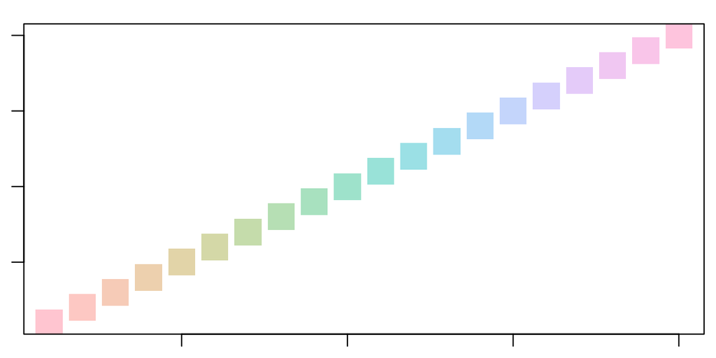

> ```r
> par(mai=c(0.2,0.2,0.2,0.1))
> plot(1:20,col=sbi$pastel(20),cex=3,pch=15)
> ```

**sbi$pca.biplot(pca,…)**

> Improved biplot for pca objects.

> The function *pca.biplot* provides an improved biplot for visualizing the pairwise scores of individual principal components of  
> an object created using the function *prcomp*. In contrast to the default  
> biplot function this plot visualizes the data as points and not row numbers, it allows to display groups using color codes and distribution ellipses.

> Arguments:
> - *pca* - pca object of class *prcomp*, created using the function *prcomp*.
> - *pcs* - the components to plot, default: c(‘PC1’,‘PC2’)
> - *pch* - plotting character, default: 19
> - *col* - plotting color, default: black
> - *arrows* - should loading arrows be displayed, default: TRUE
> - *arrow.fac* - scaling factor for arrow length, default: 1
> - *ellipse* - should 85 and 95 confidence intervals for the chisq distribution be shown. If this is shown colors for each group using the col argument must be given, default: FALSE
> - *ell.fill* - should a filled 85 percent confidence interval be shown, colors will be used from the plotting color with opacity, default: FALSE
> - *xlab* - custom xlab, if not given the PC name with variance in percent is shown, default: NULL
> - *ylab* - custom ylab, if not given the PC name with variance in percent is shown, default: NULL
> - *…* - additional arguments delegated to the standard plot function

> Returns: None

> Example:

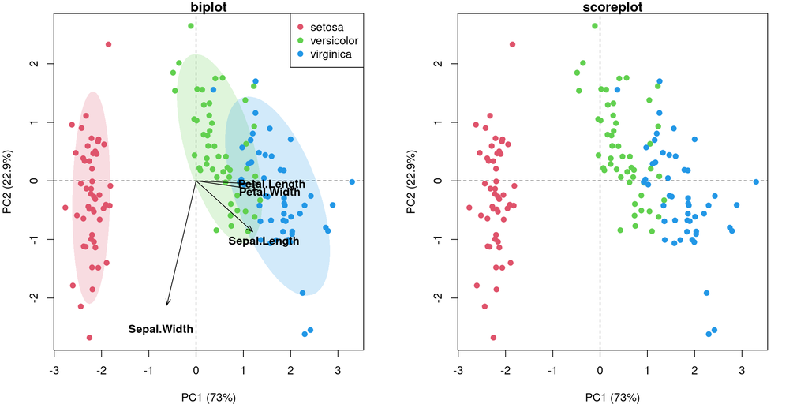

> ```r
>   par(mai=c(0.8,0.8,0.2,0.6),mfrow=c(1,2))
>   data(iris)
>   pci=prcomp(iris[,1:4],scale=TRUE)
>   sbi$pca.biplot(pci,col=rep(2:4,each=50),ellipse=TRUE,ell.fill=TRUE,
>       arrow.fac=2.3,arrows=TRUE,main="biplot")
>   legend('topright',pch=19,col=2:4,levels(iris$Species))
>   # standard score plot
>   sbi$pca.biplot(pci,col=rep(2:4,each=50),ellipse=FALSE,
>      arrow.fac=2.3,arrows=FALSE,main="scoreplot")
> ```

**sbi$pca.oncor(x,…)**

> Perform a PCA on a correlation matrix.

> The function *pca.oncor* does a PCA using eigenvector eigenvalue decomposition on a correlation matrix. PCA usually performs Pearson correlation internally what leads to a highly outlier sensitive analysis. If the user decides to use a method like spearman or even bi-seriell, polychoric or for nominal data effect size measures like cohens W this method here can be used. Note that this does not return new coordinates for the sample as the sample contribution is lost in the correlation matrix. The method might however be used to check if the results between Pearson and Spearman PCA are similar or does  
> outliers lead to a completly different result.

> Arguments:
> - *x* - a symmetric matrix usually with pairwise correlations.

> Returns: a PCA like list object with components sd and rotation

> Example:

> ```r
>   data(USArrests)
>   C=cor(USArrests)
>   sbi$pca.oncor(C)
> ```

> ```
> ## $rotation
> ##                 PC1        PC2        PC3         PC4
> ## Murder   -0.5358995  0.4181809 -0.3412327  0.64922780
> ## Assault  -0.5831836  0.1879856 -0.2681484 -0.74340748
> ## UrbanPop -0.2781909 -0.8728062 -0.3780158  0.13387773
> ## Rape     -0.5434321 -0.1673186  0.8177779  0.08902432
> ##
> ## $sdev
> ## [1] 1.5748783 0.9948694 0.5971291 0.4164494
> ```

> ```r
>   D=cor(USArrests,method="spearman")
>   sbi$pca.oncor(D)
> ```

> ```
> ## $rotation
> ##                 PC1        PC2        PC3        PC4
> ## Murder   -0.5393058  0.3885464 -0.2180789  0.7145785
> ## Assault  -0.5668864  0.1871452 -0.4471765 -0.6660703
> ## UrbanPop -0.2829154 -0.8951912 -0.2907847  0.1844883
> ## Rape     -0.5547503 -0.1124327  0.8172631 -0.1081293
> ##
> ## $sdev
> ## [1] 1.6167671 0.9752798 0.5214842 0.4036678
> ```

**sbi$pca.pairs(pca,…)**

> Improved pairs plot for pca objects.

> The function *sbi$pca.pairs* provides an improved pairs plot for visualizing the pairwise scores of the individual components of an analyses  
> using the function *prcomp*. In contrast to the default pairs function  
> this plot visualizes in the diagonal as well the variances and  
> a density line for the component scores.

> Arguments:
> - *pca* - pca object which was created using the function *prcomp*.
> - *n* - maximal number of components to visualize, default: 10
> - *groups* - vector with classes having the same length than the inout matrix for prcomp has rows, default: NULL
> - *col* - colors for the plotting, character, default: ‘black’
> - *pch* - plotting, symbol, default: 19
> - *legend* - should the legend be displayed on top, default: FALSE
> - *…* - additional arguments delegated to the standard *pairs* function

> Returns: None

> Example:

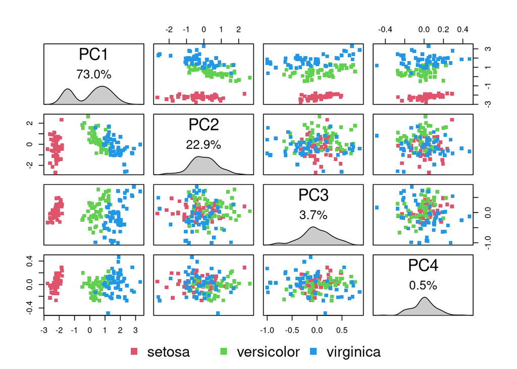

> ```r
>   data(iris)
>   pci=prcomp(iris[,1:4],scale=TRUE)
>   sbi$pca.pairs(pci,pch=15,groups=iris[,5],
>      legend=TRUE,oma=c(5,4,4,4),col=as.numeric(iris[,5])+1)
> ```

**sbi$pca.plot(pca,…)**

> Improved bar or screeplot for pca objects.

> The function *sbi$pca.plot* provides an improved bar- or screeplot for visualizing the variances of the individual components of an analyses  
> using the function *prcomp*. In contrast to the default plot function  
> this plot visualize cumulative and individual variances in percent.

> Arguments:
> - *pca* - pca object which was created using the function *prcomp*.
> - *n* - maximal number of components to visualize, default: 10
> - *type* - plotting type either “bar” or “scree”, default: “bar”
> - *cex* - character expansion for the legend and the screeplot plotting characters, default: 1.5
> - *legend* - should the legend be displayed on top, default: TRUE
> - *pc.col* - colors for the PC variances, first individual, second color for the cumulative variance, default: c(“light blue”,“grey”)
> - *…* - additional arguments delegated to the standard plot function

> Returns: None

> Example:

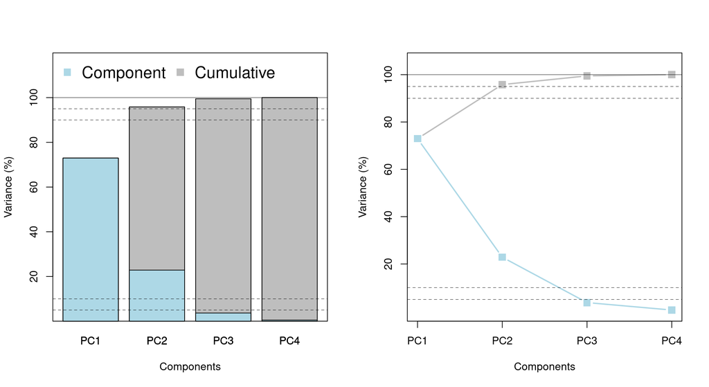

> ```r
>   data(iris)
>   par(mfrow=c(1,2))
>   pcai=prcomp(iris[,1:4],scale=TRUE)
>   sbi$pca.plot(pcai)
>   sbi$pca.plot(pcai,type="scree",legend=FALSE)
> ```

**sbi$pcor(x,y,z,method=‘pearson’)**

> Partial correlation between two variables.

> Calculate partial correlation coefficient of either parametric (“Pearson”)  
> or non-parametric (“Spearman”) statistics corrected for one or more other variables.

> Arguments:
> - *x* - numeric vector, missing values are allowed
> - *y* - numeric vector, missing values are allowed
> - *z* - numeric vector, matrix or data frame, missing values are allowed
> - *method* - character string indicating which partial correlation coefficient is to be computed, either “pearson” (default), or or “spearman”

> Returns: Estimate gives the partial correlation coefficient between x and y given z

> Examples:

> ```r
>   y.data <- data.frame(
>     hl=c(7,15,19,15,21,22,57,15,20,18),
>     disp=c(0.000,0.964,0.000,0.000,0.921,0.000,0.000,1.006,0.000,1.011),
>     deg=c(9,2,3,4,1,3,1,3,6,1),
>      BC=c(1.78e-02,1.05e-06,1.37e-05,7.18e-03,0.00e+00,0.00e+00,0.00e+00,
>           4.48e-03,2.10e-06,0.00e+00)
>   )
>   # partial correlation between "hl" and "disp" given "deg" and "BC"
>   sbi$pcor(y.data$hl,y.data$disp,y.data[,c("deg","BC")])
> ```

> ```
> ## [1] -0.6720863
> ```

> See also: sbi$pcor.test

**sbi$pcor.test(x,y,z,method=‘pearson’)**

> Partial correlation test for two variables.

> Calculate partial correlation coefficient and parametric  
> (“Pearson”) or non-parametric (“Spearman”)  
> test statistics for two variables corrected  
> for one or more other variables.

> Arguments:
> - *x* - numeric vector, missing values are allowed
> - *y* - numeric vector, missing values are allowed
> - *z* - numeric vector, matrix or data frame, missing values are allowed
> - *method* - character string indicating which partial correlation coefficient is to be computed, either “pearson” (default), or or “spearman”

> Return: List with the following components:
> - *estimate* - gives the partial correlation coefficient between x and y given z
> - *p.value* - gives the p-value of the test
> - *statistics* - gives the value of the test statistics
> - *n* - gives the number of samples after deleting all the missing samples
> - *gn* - gives the number of given variables
> - *method* - gives the correlation method used

> ```r
>   y.data <- data.frame(
>    hl=c(7,15,19,15,21,22,57,15,20,18),
>    disp=c(0.000,0.964,0.000,0.000,0.921,0.000,0.000,1.006,0.000,1.011),
>    deg=c(9,2,3,4,1,3,1,3,6,1),
>     BC=c(1.78e-02,1.05e-06,1.37e-05,7.18e-03,0.00e+00,0.00e+00,0.00e+00,
>          4.48e-03,2.10e-06,0.00e+00)
>   )
>   # partial correlation between "hl" and "disp" given "deg" and "BC"
>   sbi$pcor.test(y.data$hl,y.data$disp,y.data[,c("deg","BC")])
> ```

> ```
> ##     estimate    p.value statistic  n gn  method
> ## 1 -0.6720863 0.02619783 -2.223267 10  2 pearson
> ```

> See also:sbi$pcor

**sbi$readDataFiles(dir,fun=read.table,pattern=“.tab”,…)**

> Read a directory of data files in one data frame.

> This function reads all files in the given data directory and combines there data in one data frame. A column with the filename is added at the end to indicate from which file the data are.

> Arguments:
> - *dir* - a directory with data files
> - *fun* - function to be used for data reading, default: read.table
> - *pattern* - the filename extension pattern, default: “.tab”
> - *…* - remaining arguments are delegated to the data read function.

> Returns: data frame with all combined data and a column file at the end which ind indicates the data file.

> Examples:

> ```r
>   # not run
>   res=sbi$readDataFiles("datadir",sep="\t")
> ```

**sbi$report.pval(x,star=FALSE)**

> Return a p-value of reporting, either giving the three alpha thresholds,  
> <0.05, <0.01, or <0.001 or using the star syntax.

> Arguments:
> - *x* - a numerical p-value.
> - *star* - boolean, should the one-three star syntax be used, default: FALSE.

> Returns: pvalue in shown in alpha-threshold or star syntax.  
> If the p-value is not significant, either the value or any empty string is  
> returned if the star syntax is used.

> Example:

> ```r
>   report.pval=sbi$report.pval
>   report.pval(1/10000)
> ```

> ```
> ## [1] "<0.001"
> ```

> ```r
>   report.pval(1/10000,star=TRUE)
> ```

> ```
> ## [1] "***"
> ```

> ```r
>   report.pval(0.02,star=TRUE)
> ```

> ```
> ## [1] "*"
> ```

> ```r
>   report.pval(0.12,star=TRUE)
> ```

> ```
> ## [1] ""
> ```

> ```r
>   report.pval(c(0.001,0.01,0.3,0.02))
> ```

> ```
> ## [1] "<0.01" "<0.05" "0.30"  "<0.05"
> ```

**sbi$require(basename)**

> Source a R file which is in a parallel directory to sbi.R.

> Arguments:
> - *basename* - a filename without the file extension

> Returns: None

> Example:

> ```r
>   sbi$require("mgraph")
>   ls(mgraph)
> ```

> ```
> ##  [1] "autonames"      "components"     "connect"        "d2u"
> ##  [5] "data2graph"     "degree"         "FILENAME"       "graph2data"
> ##  [9] "kroki"          "layout"         "new"            "nodeColors"
> ## [13] "plot"           "shortest.paths" "summary"        "u2d"
> ## [17] "VERSION"
> ```

**sbi$shape(x=0,y=0,width=1,height=1,type=“circle”,…)**

> create polygon shapes centered at given x and y coordinates.

> Arguments:
> - *x* - horizontal center of shape, default: 0
> - *y* - vertical center of shape, default: 0
> - *width* - the shape width, default: 1
> - *height* - the shape height, default: 1
> - *seed* - set a seed for a random polygon, default: 17

> Returns: polygon as list of x and y coordinates

> Example:

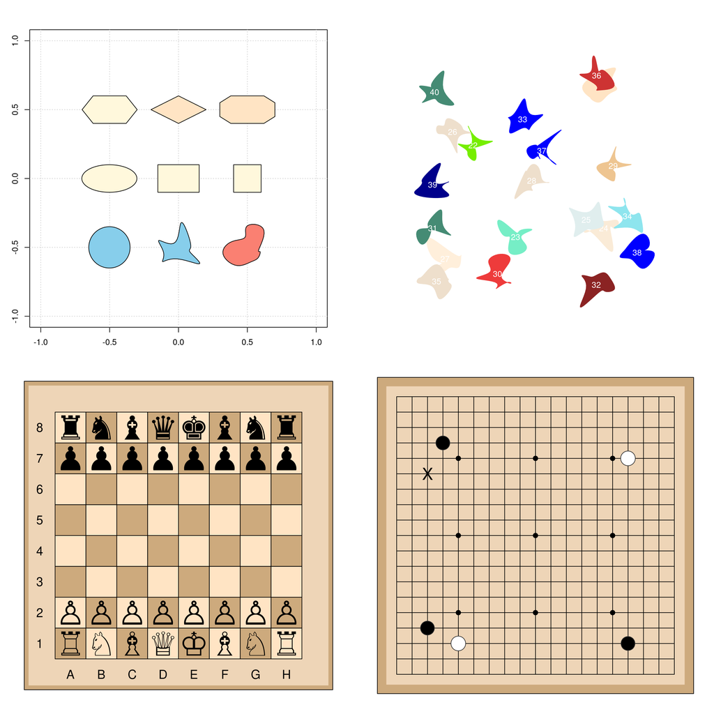

> ```r
> par(mfrow=c(2,2),mai=rep(0.5,4))
> plot(1,xlim=c(-1,1),ylim=c(-1,1),axes=TRUE,xlab="",ylab="",type="n")
> grid()
> polygon(sbi$shape(-0.5,-0.5,type="circle",width=0.3,height=0.3),col="skyblue")
> polygon(sbi$shape(0,-0.5,type="rand",width=0.3,height=0.3),col="skyblue")
> polygon(sbi$shape(0.5,-0.5,type="rand",width=0.3,height=0.3,seed=19),col="salmon")
> polygon(sbi$shape(-0.5,0,type="circle",width=0.4,height=0.2),col="cornsilk")
> polygon(sbi$shape(0,0,type="rect",width=0.3,height=0.2),col="cornsilk")
> polygon(sbi$shape(0.5,0,type="rect",width=0.2,height=0.2),col="cornsilk")
> polygon(sbi$shape(-0.5,0.5,type="hexagon",width=0.4,height=0.2),col="cornsilk")
> polygon(sbi$shape(0,0.5,type="diamond",width=0.4,height=0.2),col="bisque")
> polygon(sbi$shape(0.5,0.5,type="octagon",width=0.4,height=0.2),col="bisque")
> plot(1,xlim=c(-1,1),ylim=c(-1,1),axes=FALSE,xlab="",ylab="",type="n")
> for (i in 1:20) {
>    col=colors()[sample(2:50,1)]
>    x=runif(1,min=-0.8,max=0.8)
>    y=runif(1,min=-0.8,max=0.8)
>    polygon(sbi$shape(x,y,type="rand",width=0.25,height=0.25,
>       seed=20+i),col=col,border=col)
>    text(x,y,20+i,col="white")
> }
> # chessboard
> par(mai=rep(0.2,4))
> plot(1,xlim=c(-0.5,9.5),ylim=c(-0.5,9.5),axes=FALSE,xlab="",ylab="",type="n")
> cols=c(rep(c("burlywood3","bisque"),4),rep(c("bisque","burlywood3"),4))
> c=0
> polygon(sbi$shape(4.5,4.5,type="rect",width=10,height=10),col="burlywood3")
> polygon(sbi$shape(4.5,4.5,type="rect",width=9.8,height=9.8),col="bisque2",border="burlywood3",lwd=4)
> for (col in 1:8) {
>    for (row in 1:8) {
>       c=c+1
>       polygon(sbi$shape(col,row,type="rect",width=1,height=1),col=cols[c])
>       if (c==16) { c = 0 }
>    }
> }
> text(1:8,rep(0,8),LETTERS[1:8],cex=1.5)
> text(rep(0,8),1:8,1:8,cex=1.5)
> text(1:8,1,c("\u2656","\u2658","\u2657","\u2655",
>              "\u2654","\u2657","\u2658","\u2656"),cex=4)
> text(1:8,2,rep("\u2659",8),cex=4)
> text(1:8,7,rep("\u265F",8),cex=4)
> text(1:8,8,c("\u265C","\u265E","\u265D","\u265B",
>              "\u265A","\u265D","\u265E","\u265C"),cex=4)
> # Go board
> plot(1,xlim=c(0,20),ylim=c(0,20),axes=FALSE,xlab="",ylab="",type="n")
> polygon(sbi$shape(10,10,type="rect",width=20.5,height=20.5),col="burlywood3")
> polygon(sbi$shape(10,10,type="rect",width=19.5,height=19.5),col="bisque2",border="burlywood3",lwd=4)
> # grid
> res=lapply(1:19, function (x) lines(c(x,x),c(1,19),lwd=1))
> res=lapply(1:19, function (x) lines(c(1,19),c(x,x),lwd=1))
> # markers
> for (i in c(5,10,15)) {
>     for (j in c(5,10,15)) {
>        polygon(sbi$shape(i,j,type="circle",width=0.3,height=0.3),col="black")
>     }
> }
> # some stones
> set = function (x,y,col="black") {
>     w=0.9
>     if (col=="white") {
>        w=0.95
>     }
>     polygon(sbi$shape(x,y,type="circle",width=w,height=w),col=col,border="grey20")
> }
> set(3,4,"black")
> set(5,3,"white")
> set(16,3,"black")
> set(16,15,"white")
> set(4,16,"black")
> text(3,14,"X",cex=2) # set suggestion
> ```

**sbi$shell(script)**

> Executes a given shell script in text format (Unix only).

> Arguments:
> - *script* - text of a shell script
> - *filename* - the script filename, default: “shell-script.sh”

> Returns: command output

> Example:

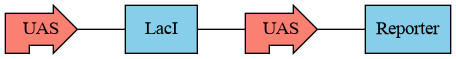

> ```r
> sbi$shell("#!/usr/bin/env -S dot -Tpng -odot.png
> digraph G {
> rankdir=LR;
>   node[style=filled,fillcolor=skyblue];
>   a -> b [arrowhead=none];
>   b -> c [arrowhead=none];
>   c -> d [arrowhead=none];
>   a [shape=rpromoter,label=\"UAS\",fillcolor=salmon];
>   b [shape=rectangle,label=\"LacI\"];
>   c [shape=rpromoter,label=\"UAS\",fillcolor=salmon];
>   d [shape=rectangle,label=\"Reporter\"];
> }
> ")
> ```

> The resulting png file must be embedded using standard Markdown Syntax:

> ```
> ![](dot.png)
> ```

> See also:
> - Example is from https://caretdashcaret.com/2012/08/27/graphviz/)
> - Graphivz guide:
>   - [Dot guide](https://www.graphviz.org/pdf/dotguide.pdf)
>   - [More shapes](http://www.graphviz.org/doc/info/shapes.html)

**sbi$sem(x,na.rm=FALSE)**

> Calculate the standard error of the mean for a given numerical vector.

> Arguments:
> - *x* - a numerical vector.
> - *na.rm* - logical vecor indicating if missing values should be removed, default: FALSE

> Returns: computed standard error of the mean.

> Example:

> ```r
>   sem=sbi$sem
>   sem(rnorm(50,mean=10,sd=3))
> ```

> ```
> ## [1] 0.444186
> ```

> ```r
>   sem(rnorm(1000,mean=10,sd=3))
> ```

> ```
> ## [1] 0.09387643
> ```

**sbi$skewness(x,na.rm=FALSE)**

> Calculate the third central moment of a distribution. Values higher than zero indicate right-tailed distributions, values of lower than zero mean  
> left-tailed distributions. Values around zero mean normal value like distribution.

> Arguments:
> - *x* - vector with positive numerical values.
> - *na.rm* - should NA’s be removed, default: FALSE

> Returns: numerical value for the skewness of the vector.

> Example:

> ```r
>   sbi$skewness(1:100)          # very uniform, 0
> ```

> ```
> ## [1] 0
> ```

> ```r
>   sbi$skewness(rnorm(100))     # normal, close to 0
> ```

> ```
> ## [1] 0.07665236
> ```

> ```r
>   # now with right tail
>   sbi$skewness(c(rnorm(100,mean=20),rnorm(30,mean=23,sd=2)))
> ```

> ```
> ## [1] 1.183262
> ```

> See also: sbi$kurtosis

**sbi$smartbind(x,y)**

> Combine two data frames via rbind even with different column names.

> This function combines two data frames or matrices even if they have different column names. In each data frame or matrix missing columns are first filled up with NA’s. Thereafter data is fused using rbind. Column order is determined based  
> on the first given data.

> Arguments:
> - *x* - data frame or matrix
> - *y* - data frame or matrix

> Returns: data frame or matrix, depending on the given input where data from *x* and *y* are combined using rbind. Missing columns in either of the data frame are filled up with NA’s.

> Examples:

> ```r
>   ir1=cbind(rn1=rnorm(nrow(iris)),iris)
>   ir2=cbind(iris,rn2=rnorm(nrow(iris),mean=10))
>   head(sbi$smartbind(ir1,ir2))
> ```

> ```
> ##           rn1 Sepal.Length Sepal.Width Petal.Length Petal.Width Species rn2
> ## 1 -0.49288249          5.1         3.5          1.4         0.2  setosa  NA
> ## 2 -0.01817275          4.9         3.0          1.4         0.2  setosa  NA
> ## 3  0.12627325          4.7         3.2          1.3         0.2  setosa  NA
> ## 4  0.96443253          4.6         3.1          1.5         0.2  setosa  NA
> ## 5 -0.67505081          5.0         3.6          1.4         0.2  setosa  NA
> ## 6 -0.15366039          5.4         3.9          1.7         0.4  setosa  NA
> ```

> ```r
>   tail(sbi$smartbind(ir1,ir2))
> ```

> ```
> ##     rn1 Sepal.Length Sepal.Width Petal.Length Petal.Width   Species       rn2
> ## 295  NA          6.7         3.3          5.7         2.5 virginica  7.756528
> ## 296  NA          6.7         3.0          5.2         2.3 virginica  8.678884
> ## 297  NA          6.3         2.5          5.0         1.9 virginica 10.625475
> ## 298  NA          6.5         3.0          5.2         2.0 virginica 11.923743
> ## 299  NA          6.2         3.4          5.4         2.3 virginica  9.233243
> ## 300  NA          5.9         3.0          5.1         1.8 virginica  8.525376
> ```

**sbi$venn(x,…)**

> Plot Venn diagram for logical relations between two or three sets.

> Arguments:
> - *x* - data frame or matrix or vector, in the latter case y and for 3 sets as well z must be given
> - *y* - vector if *x* is vector, default: NULL
> - *z* - vector if *x* and *y* are vectors, default: NULL
> - *vars* - variable names to display if x, y and z are vectors, default: NULL
> - *col* - background colors for the circles, default: c(“#cc888899”,“#8888cc99”,“#88cc8899”)
> - *cex* - character expansion for the text characters, default: 1.6
> - *…* - argument delegated to the plot function Returns: Nothing

> Examples:

[figure not shown]

> ```r
> X=matrix(rnorm(2700),ncol=3)
> colnames(X)=c("A","B","C")
> X=X>0.4
> Y=X[,1:2]
> Y=Y>0.7
> par(mfrow=c(2,2),mai=rep(0.1,4),pty='s')
> sbi$venn(X)
> sbi$venn(Y)
> sbi$venn(x=LETTERS[1:9],y=LETTERS[3:6],z=LETTERS[4:12],vars=c('Xvar','Yvar','Zvar'))
> sbi$venn(x=LETTERS[1:9],y=LETTERS[3:6],vars=c('Xvar','Yvar'))
> ```

## Operators

**lhs %ni% rhs - not-in operator**

> The not-in operator *%ni%* is the inverse of the in-operator *%in%*.

> Arguments:
> - *lhs* - a R vector
> - *rhs* - a R vector

> Example:

> ```r
>   v1=1:5
>   v2=3:7
>   v1 %ni% v2
> ```

> ```
> ## [1]  TRUE  TRUE FALSE FALSE FALSE
> ```

> ```r
>   v2 %ni% v1
> ```

> ```
> ## [1] FALSE FALSE FALSE  TRUE  TRUE
> ```

**lhs %>% rhs - pipe operator**

> Pipe an object forward into a function or call expression. Unlike the `magrittr` pipe, you must supply an actual function  
> instead of just a function name. For example `mtcars %>% head` will not work, but `mtcars %>% head()` will.

> Please note, that since version 4.1 has a default pipe operator `|>’, here an interesting [article](https://www.infoworld.com/article/3621369/use-the-new-r-pipe-built-into-r-41.html).

> Arguments:
> - *lhs* - the result you are piping.
> - *rhs* - Where you are piping the result to.

> Examples:

> ```r
>   data(mtcars)
>   mtcars %>% head()
> ```

> ```
> ##                    mpg cyl disp  hp drat    wt  qsec vs am gear carb
> ## Mazda RX4         21.0   6  160 110 3.90 2.620 16.46  0  1    4    4
> ## Mazda RX4 Wag     21.0   6  160 110 3.90 2.875 17.02  0  1    4    4
> ## Datsun 710        22.8   4  108  93 3.85 2.320 18.61  1  1    4    1
> ## Hornet 4 Drive    21.4   6  258 110 3.08 3.215 19.44  1  0    3    1
> ## Hornet Sportabout 18.7   8  360 175 3.15 3.440 17.02  0  0    3    2
> ## Valiant           18.1   6  225 105 2.76 3.460 20.22  1  0    3    1
> ```

> ```r
>   mtcars %>% subset(select=c(mpg,cyl,disp,drat)) %>% head()
> ```

> ```
> ##                    mpg cyl disp drat
> ## Mazda RX4         21.0   6  160 3.90
> ## Mazda RX4 Wag     21.0   6  160 3.90
> ## Datsun 710        22.8   4  108 3.85
> ## Hornet 4 Drive    21.4   6  258 3.08
> ## Hornet Sportabout 18.7   8  360 3.15
> ## Valiant           18.1   6  225 2.76
> ```

> Note: Code is from Nathan Eastwood, from his poorman package, LICENSE as well MIT.

## Citation

How to cite this package:

```
# notrun
@Misc{Groth2022sbi,
  author =   {Detlef Groth},
  title =    {sbi.R: {R} functions for Statistical Bioinformatics},
  howpublished = {\url{https://github.com/mittelmark/Rcode}},
  year = {2022}
}
```

Groth, D. (2022). sbi.R - R functions for Statistical Bioinformatics. https://github.com/mittelmark/Rcode

## Documentation

This documentation was created directly from the file *sbi.R* using the following commands in the terminal using the Rmarkdown package:

```
# notrun
Rscript --eval
```

Alternatively you can just extract the plain documentation without output of the code chunks like this:

```
# not run
Rscript --docu
```

## Disclaimer

This file contains a few important R functions to be used for illustration. The functions have much less error checking than function you can find in R packages available on CRAN. If you do serious statistical analysis I recommend to use those packages. Here is a list of packages I recommend very much:

- vcd
- corrplot
- e1071
- effectsize
- argparser
- diagram

## ChangeLog

- 2022-01-30 - Version 0.1
- 2022-02-02 - Version 0.2
  - new function mkdoc
  - new function shell
  - new function shape
  - fix report.pval
  - docu extensions, fixes
- 2022-03-03 - Version 0.3
  - adding venn-plot
  - bezier curves and flow update
- 2022-03-31 - Version 0.4
  - fix for source with variable name
  - fix for Rscript call using variables
- 2022-04-25 - Version 0.5
  - sbi$mkdoc support for `## include "header.md"` constructs
- 2022-05-09 - Version 0.6
  - changing idx variable to .idx to avoid overwriting
  - adding require method to load other R files in parallel
  - fix for file.head, closing connection

## Copyright

Copyright @ 2022 - Detlef Groth, University of Potsdam

License: MIT - License